# 9 Visualizing data distributions

## 9.8.6 Quick plots

In Section 8.13 we introduced **`qplot`** as a useful function when we need to make a quick scatterplot. We can also use `qplot` to make histograms, density plots, boxplot, qqplots and more. Although it does not provide the level of control of ggplot, `qplot` is definitely useful as it permits us to make a plot with a short snippet of code.

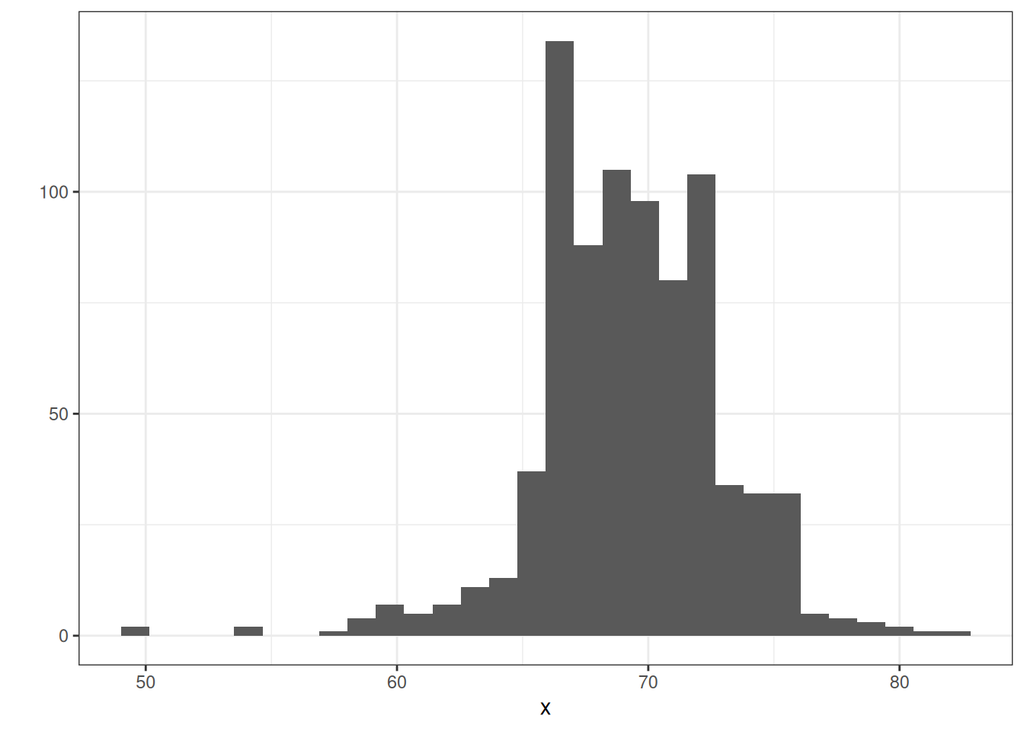

```r
heights |>
  filter(sex == "Male") |>
  pull(height) -> x
qplot(x)
```

The function guesses that we want to make a histogram because we only supplied one variable. In Section 8.13 we saw that if we supply `qplot` two variables, it automatically makes a scatterplot.

To make a quick `qqplot` you have to use the sample argument. Note that we can add layers just as we do with ggplot.

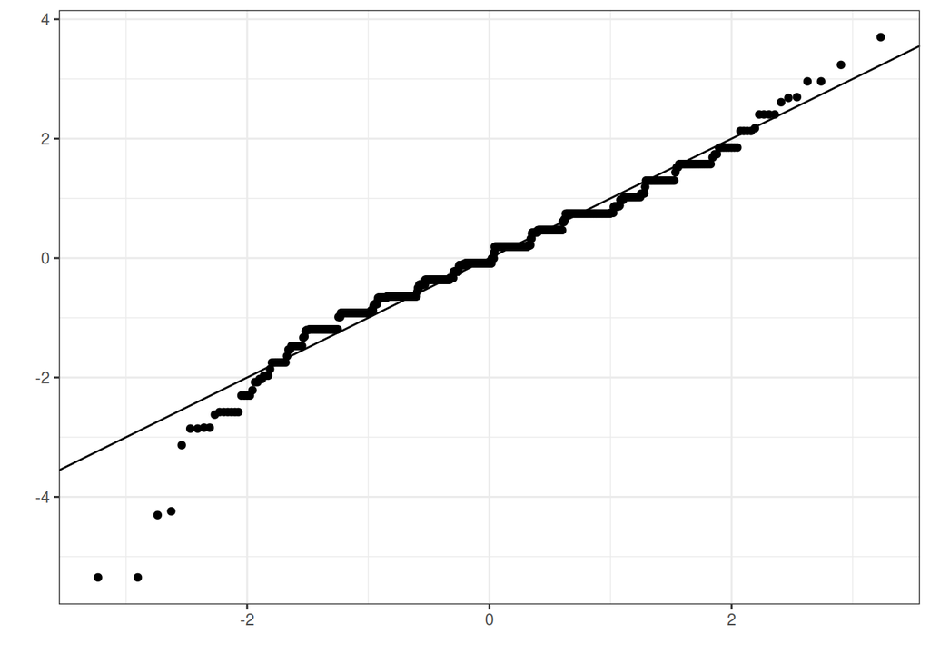

```r
qplot(sample = scale(x)) +
  geom_abline()
```

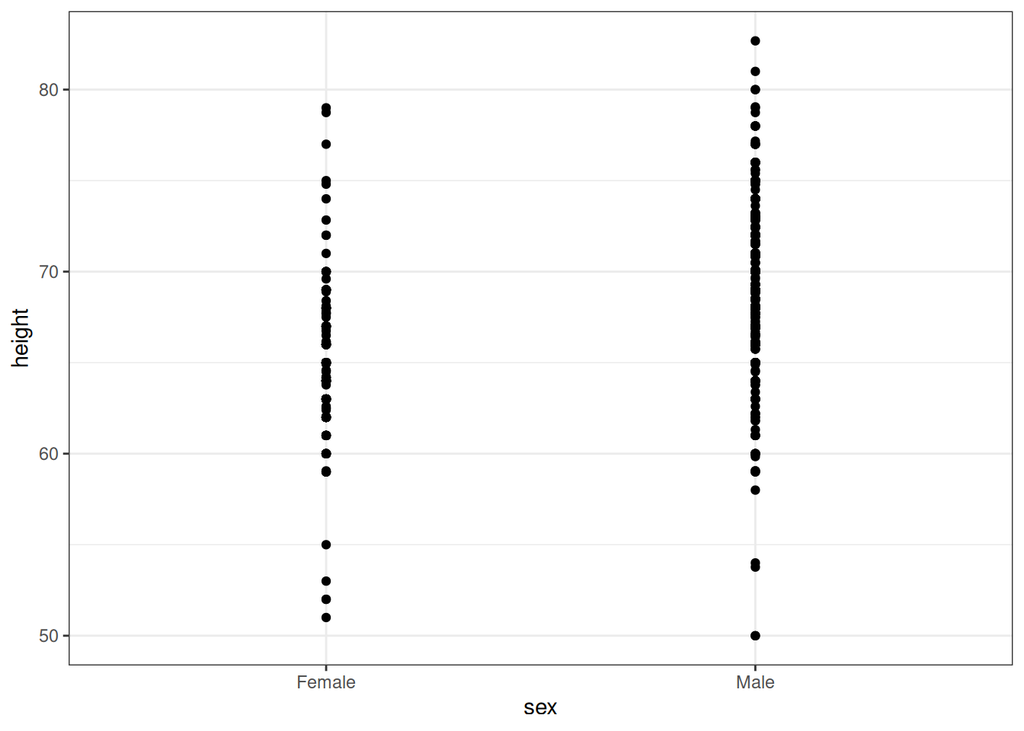

```r
height <- heights |> pull(height)
sex <- heights |> pull(sex)
qplot(sex, height)
```

NB. The code above is different from the code in the book, which is `heights |> qplot(sex, height, data = .)`. This failed with “Object”.” not found. I can’t be certain that the plot above is the intended one, but it seems to be.

We can also select a specific geometry by using the `geom` argument. So to convert the plot above to a boxplot, we use the following code:

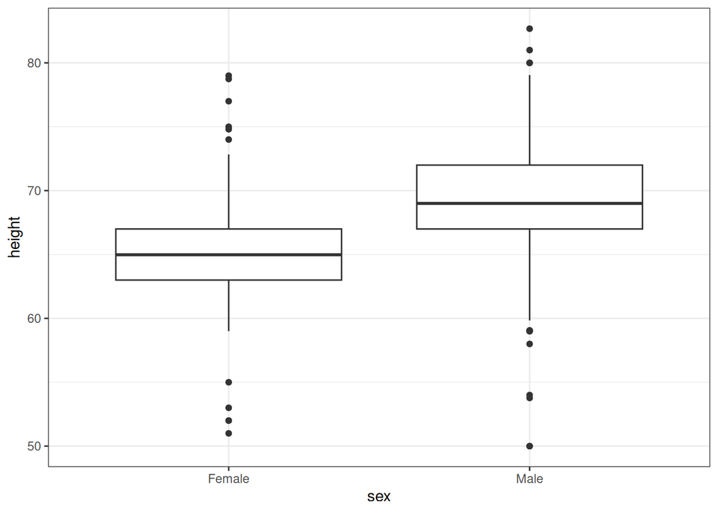

```r
sex <- heights |> pull(sex)
qplot(sex, height, geom = "boxplot")
```

We can also use the `geom` argument to generate a density plot instead of a histogram:

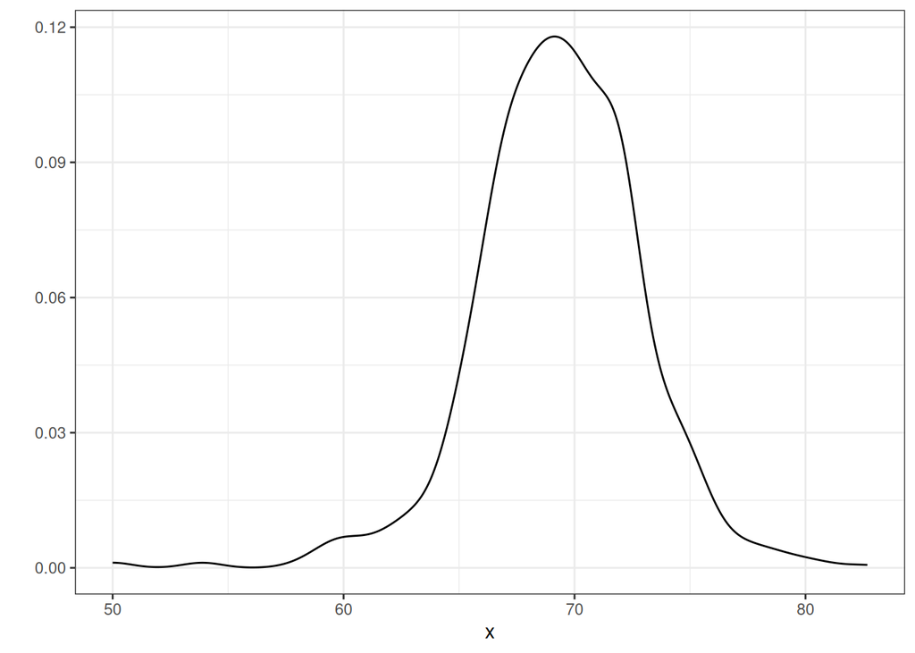

```r
qplot(x, geom = "density")
```

Although not as much as with ggplot, we do have some flexibility to improve the results of qplot. Looking at the help file we see several ways in which we can improve the look of the histogram above. Here is an example:

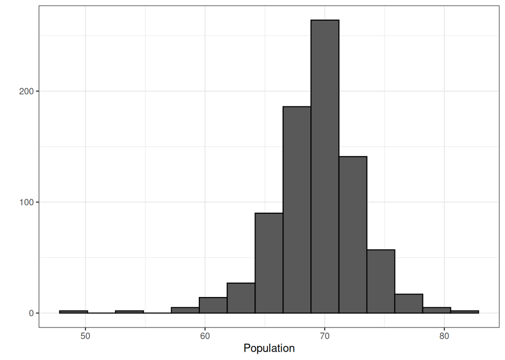

```r
qplot(x,
      bins = 15,
      color = I("black"),
      xlab = "Population")
```

NB. from the docs for **`I()`**, the `as is` function

> Protecting an object by enclosing it in `I()` in a call to **data.frame** inhibits the conversion of character vectors to factors and the dropping of names, and ensures that matrices are inserted as single columns.